# Reproducible Research Project 1

pfirns

7 March 2016

### 1. Code for reading in the dataset and/or processing the data

```r
temp <- tempfile()
download.file("https://d396qusza40orc.cloudfront.net/repdata%2Fdata%2Factivity.zip",temp)
activity <- read.csv(unz(temp, "activity.csv"))
unlink(temp)
head(activity)
```

```
##   steps       date interval
## 1    NA 2012-10-01        0
## 2    NA 2012-10-01        5
## 3    NA 2012-10-01       10
## 4    NA 2012-10-01       15
## 5    NA 2012-10-01       20
## 6    NA 2012-10-01       25
```

### 2. Histogram of the total number of steps taken each day

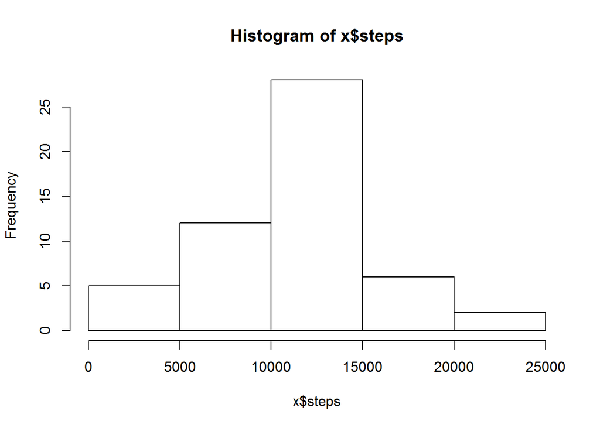

```r
x <- aggregate(steps ~ date, data = activity, sum)
hist(x$steps)
```

### 3. Mean and median number of steps taken each day

```r
mean(x$steps)
```

```
## [1] 10766.19
```

```r
median(x$steps)
```

```
## [1] 10765
```

### 4. Time series plot of the average number of steps taken

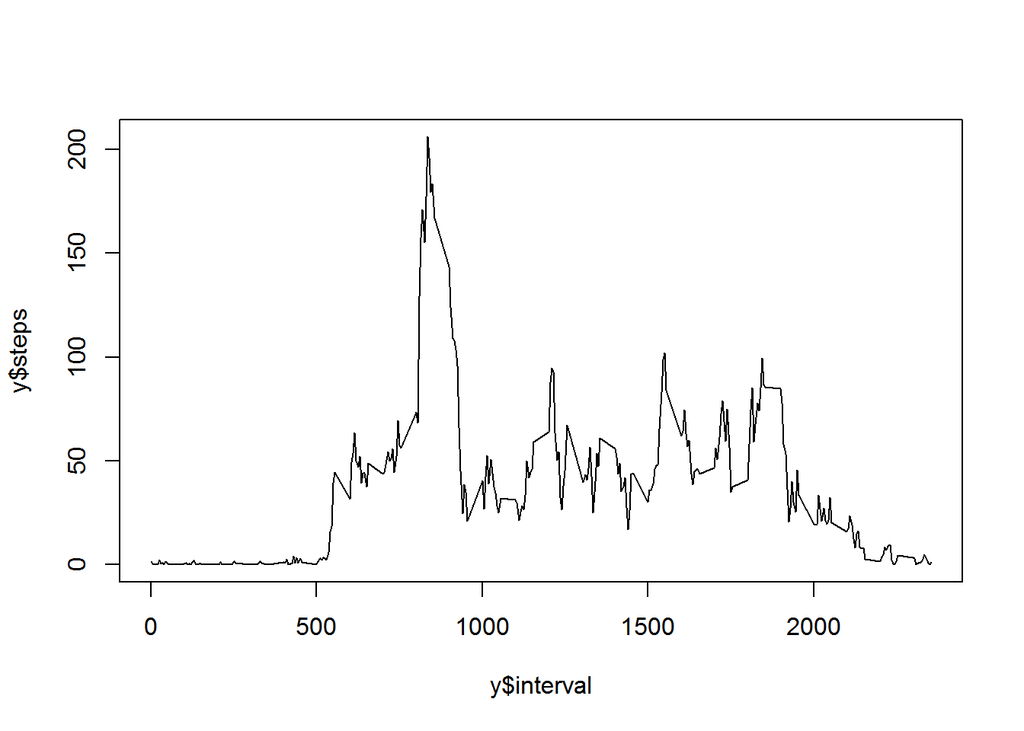

```r
y <- aggregate(steps ~ interval, data = activity, mean)
plot(y$interval, y$steps,type = "l")
```

### 5. The 5-minute interval that, on average, contains the maximum number of steps

Using the subset function to retrieve the row where the average number of steps by interval is equal to the maximum for all intervals, the result is: **Interval 835 with average 206.1698 steps**

```r
subset(y[y$steps==max(y$steps),])
```

```
##     interval    steps
## 104      835 206.1698
```

### 6. Code to describe and show a strategy for imputing missing data

First, calculate the total number of missing values:

```r
sum(is.na(activity$steps))
```

```
## [1] 2304
```

The stratagy I have chosen is to take the rounded interval mean and assign this to the missing values. This strategy is implemented in the following code - resulting in data frame activity2 which is equal to the original dataset but with the missing values filled in. The effect of imputing values in this case is to skew the data to the left as most of the missing values appeared to be in the early intervals.

```r
intervalMeans <- round(aggregate(steps ~ interval, data = activity, mean))
z <- merge(activity, intervalMeans, by.x = "interval", by.y = "interval")
z$steps.x[is.na(z$steps.x)==TRUE] <- z$steps.y
activity2 <- data.frame(steps = z$steps.x, date = z$date, interval = z$interval)
head(activity2)
```

```
##   steps       date interval
## 1     2 2012-10-01        0
## 2     0 2012-11-23        0
## 3     0 2012-10-28        0
## 4     0 2012-11-06        0
## 5     0 2012-11-24        0
## 6     0 2012-11-15        0
```

### 7. Histogram of the total number of steps taken each day after missing values are imputed

First, the data is aggregated and then the histogram created.

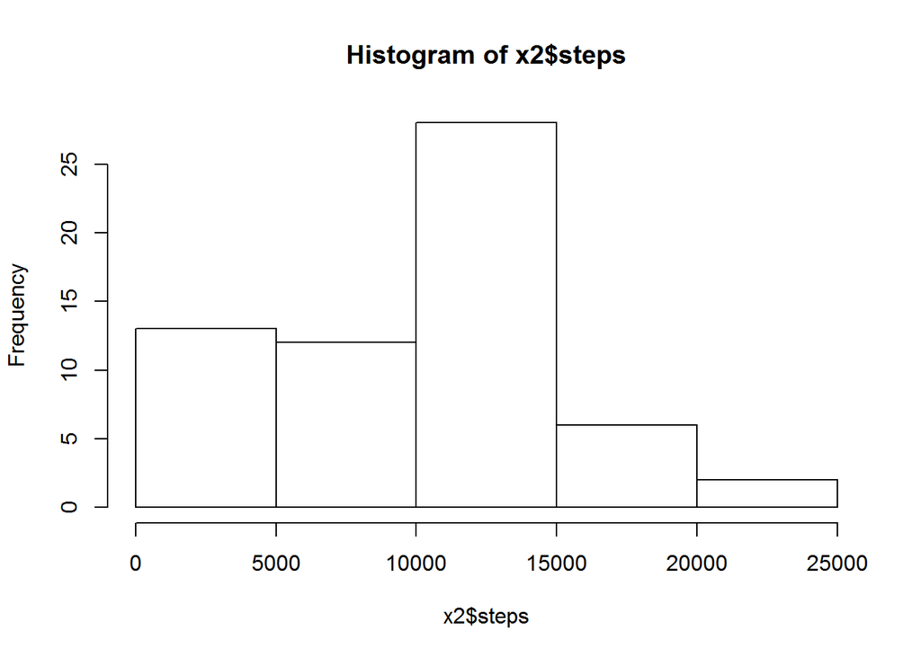

```r
x2 <- aggregate(steps ~ date, data = activity2, sum)
hist(x2$steps)
```

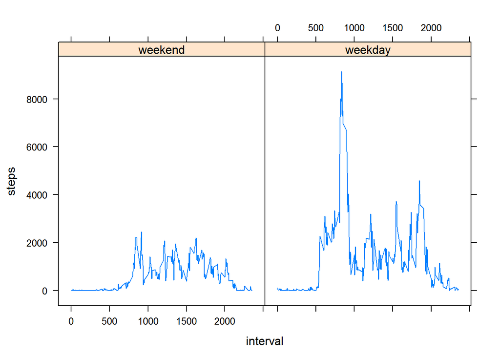

```r
library(lattice)
activity2$date <- as.Date(activity2$date)
weekdays1 <- c('Monday', 'Tuesday', 'Wednesday', 'Thursday', 'Friday')
activity2$wDay <- factor((weekdays(activity2$date) %in% weekdays1), levels=c(FALSE, TRUE), labels=c('weekend', 'weekday'))
activity3 <- aggregate(steps ~ interval + wDay, data = activity2, sum)
xyplot(steps~interval|wDay,activity3,type='l')
```

### 9. All of the R code needed to reproduce the results (numbers, plots, etc.) in the report

Code is included in all of the above above steps